# Tarea 4 Inferencia Estadística

Hairo Ulises Miranda Belmonte

2 de Octubre de 2018

## EJERCICIO 2

1. Escriba la siguiente funciónn en R. Simule una muestra de tamañoo n de una variable aleatoria Exponencial($\lambda$) y calcule el estadístico $Z_{n}= \sqrt{n}(X_{n}-\lambda^{-1})/ \lambda^{-1}$. Repita lo anterior m veces. La función deberá tomar como parámetros n, m y $\lambda$ y regresar un vector de tamaño n conteniendo la muestra de $Zn$.

```r
Zn <- function(n, lambda, m) {
set.seed(0)
Z <- rep(0, m)
Z <- replicate(m, (sqrt(n)*(mean(rexp(n, lambda))-(lambda)^(-1)))/(lambda)^(-1))
return(Z)
}
```

2. Para $n = 5, 10, 100, 500, 1000, 10000$, $m = 1000$ y $\lambda=1$, utilice la función del inciso anterior para obtener muestras de $Zn$. Grafíque las muestras anteriores en un histograma (un histograma para cada n). ¿Qué observa? ¿Qu´e tiene que ver su resultado con el TCLC?

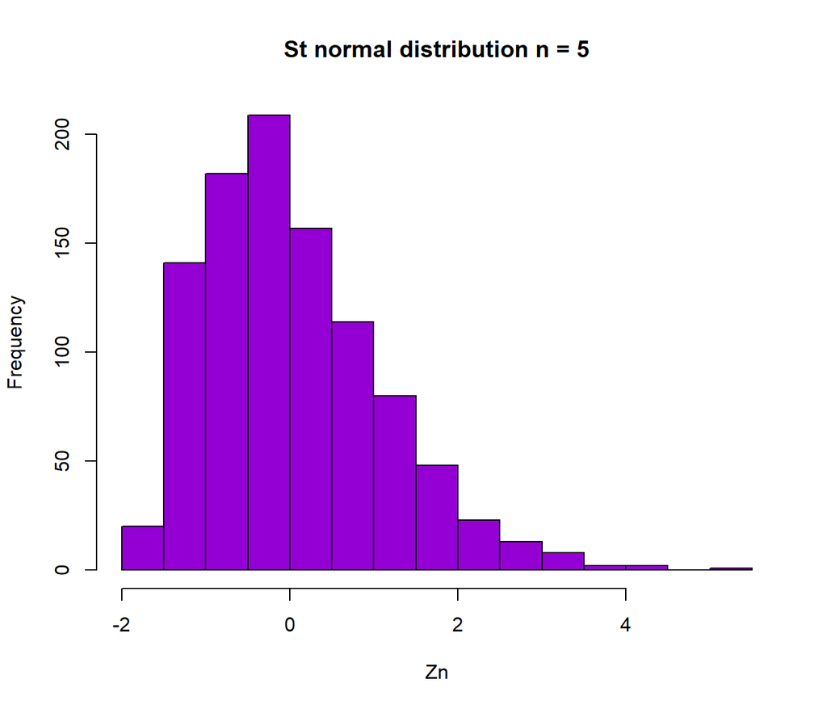

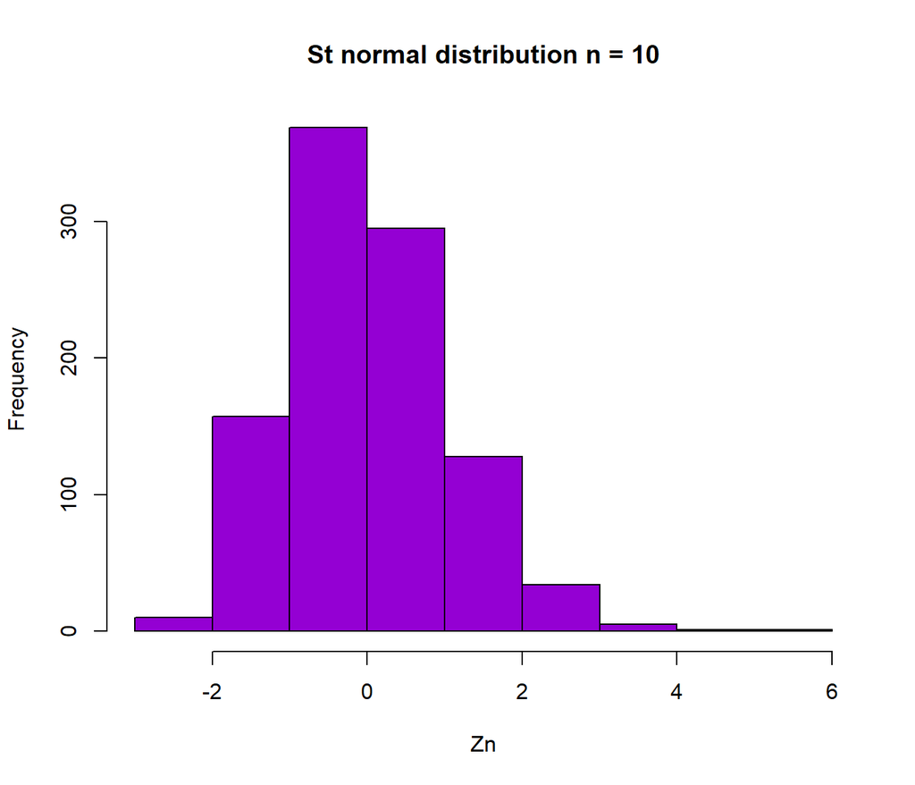

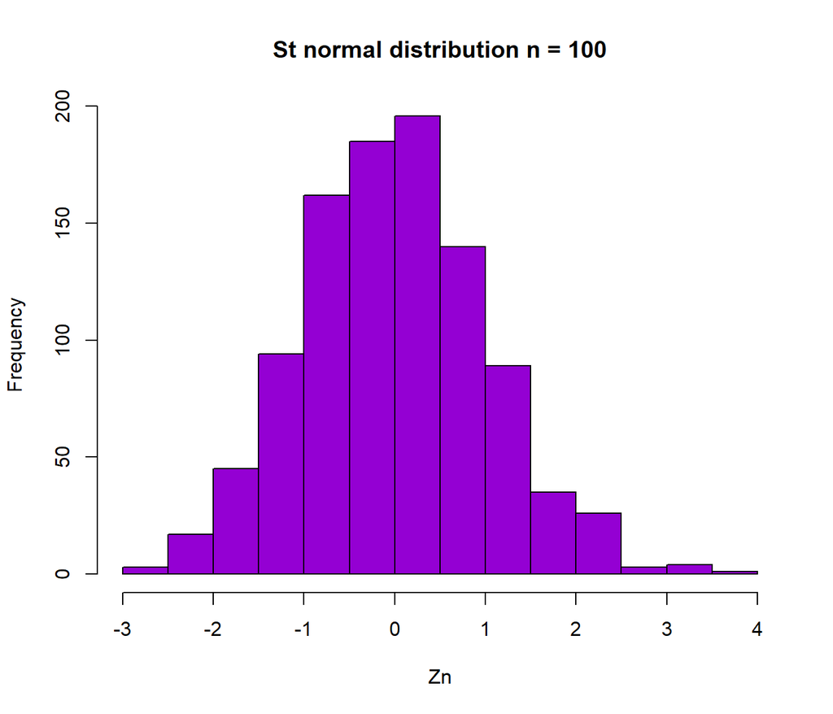

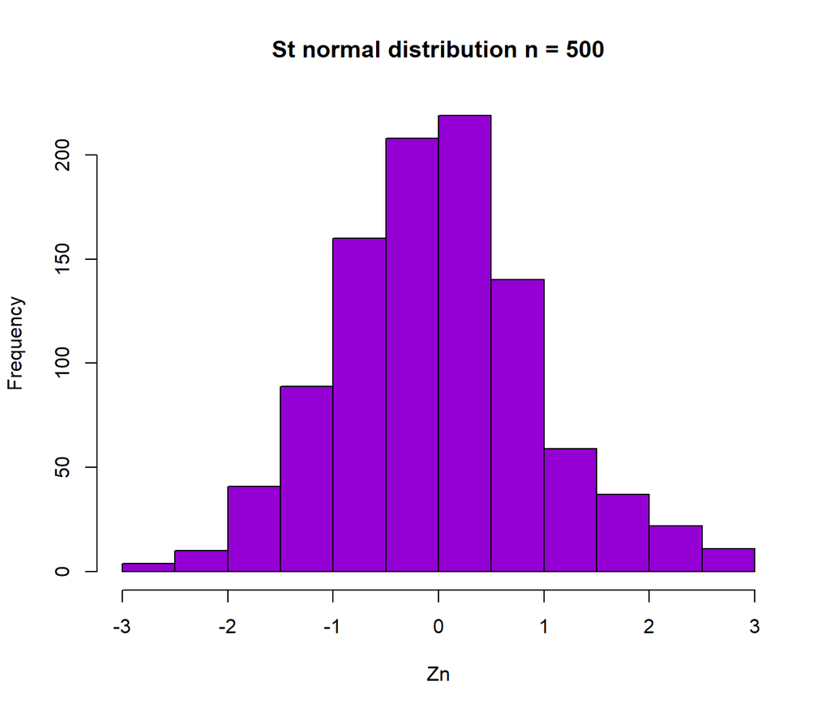

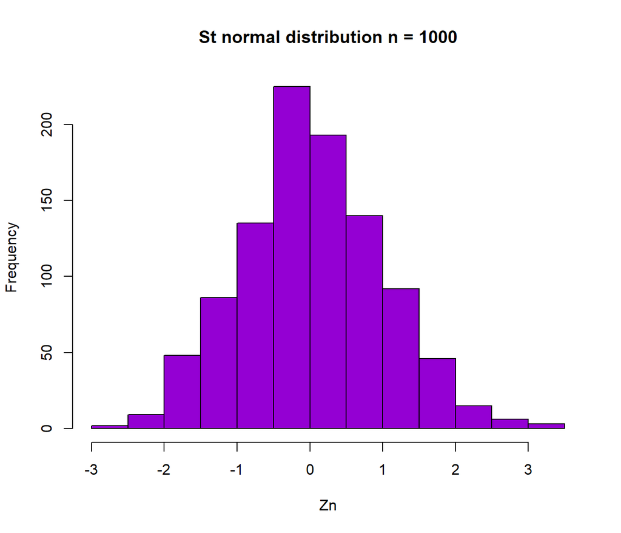

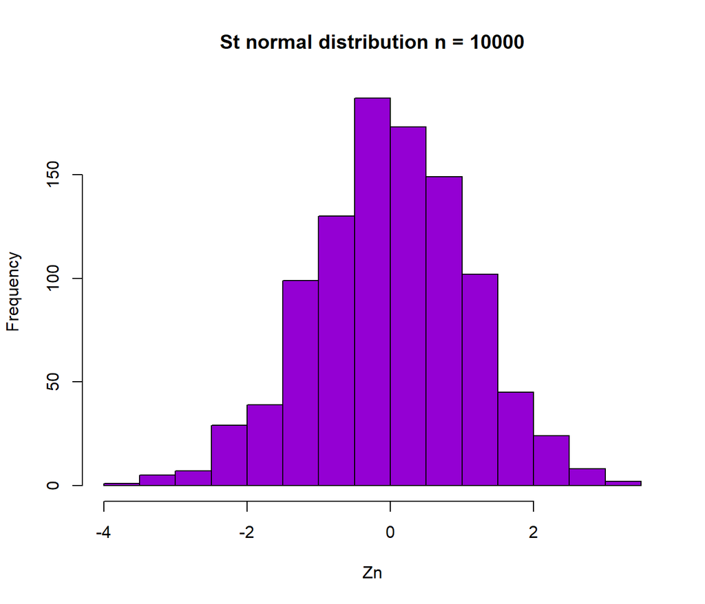

```r
n <- c(5, 10, 100, 500, 1000, 10000)
i <- 1:6
Muestra <<- matrix(0L, 1000, 6)
auxiliar <- sapply(i, function(i) hist(Muestra[, i] <<- Zn(n[i], 1, 1000), main = paste("St normal distribution n =", n[i]),
     xlab = "Zn",  col ="darkviolet", border = "black") )
```

¿Qué observa? Se observa que al repetir el calculo del estadístico 1000 veces, y el valor de n se vuelve cada vez más grande, la variable aleatoria Zn, presenta una distribución limite parecida a la normal estandar.

¿Qué tiene que ver su resultado con TCL? El teorema nos dice que una secuencia de variables aleatorias independientes e indenticamentes distribuidas - en nuestro caso las exponenciales con parámetro lambda-, cuya generadora de momentos exista, y con ello media y varianza sea finita. Entonces, al normalizar la media de la secuencia de variables aleatorias e incrementar n, la variable aleatoria estandar tiende a una distribución límite, la cual es una normal estandar. Por lo tanto, al normalizar cualquier variable aleatoria , pero que cumpla con lo necesarios previamente mencionado, entonces, dicha sucesión de variables estadarizadas convergerá en distribución a una normal estandar.

3. Para cada una de las muestras generadas en el inciso anterior, encuentre el Q-Q plot y el P-P plot normales. Comente sus resultados.

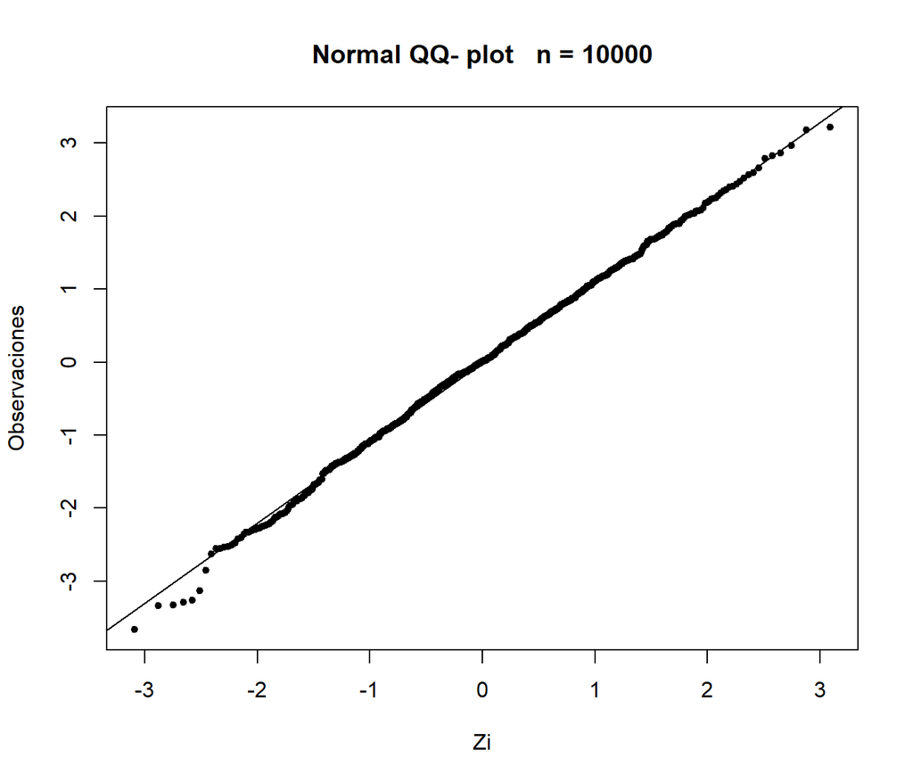

```r
# # # # # # # # # # # # # # # # # # # # # # # #  # #
# Función : qqplotFunction
# Gráfica qq-plot
#
# Input: Datos
# Outpu: QQ-PLOT gráfica
# # # # # # # # # # # # # #  # # # # # # # # # # # #
#qqplot
qqplotFunction<-function(data, sizeSample){
  sort(data)
  n <- length(data)
  x <- 1:length(data)
  p <- x/(n+1)

  teorico <-qnorm(c(0.25, 0.75))
  estimado <- quantile(data, c(0.25, 0.75))
  slope <- diff(estimado) / diff(teorico)
  int <- estimado[1] - slope * teorico[1]
  plot(qnorm(p), sort(data),  type = "p",
       ylab = "Observaciones", xlab ="Zi",
       main = paste("Normal QQ- plot   n =", sizeSample), pch=20)
  abline(int, slope)

}

qqplotFunction(Muestra[ ,6], n[6])
```

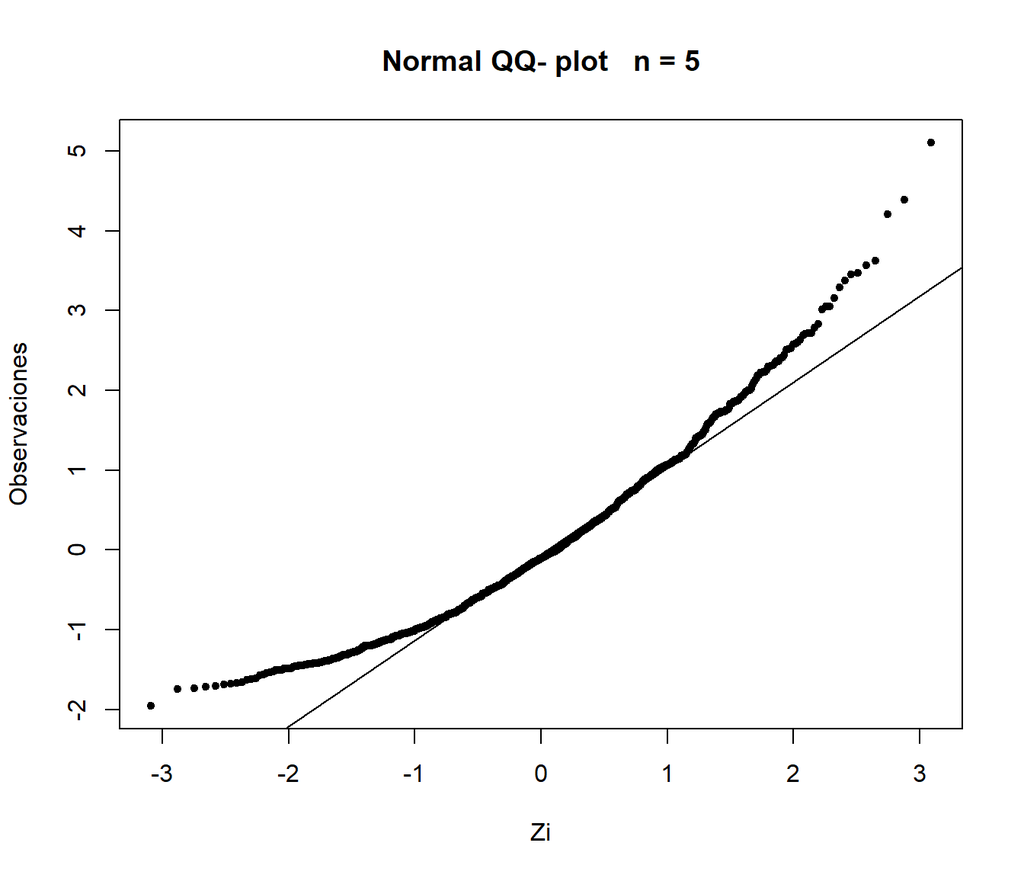

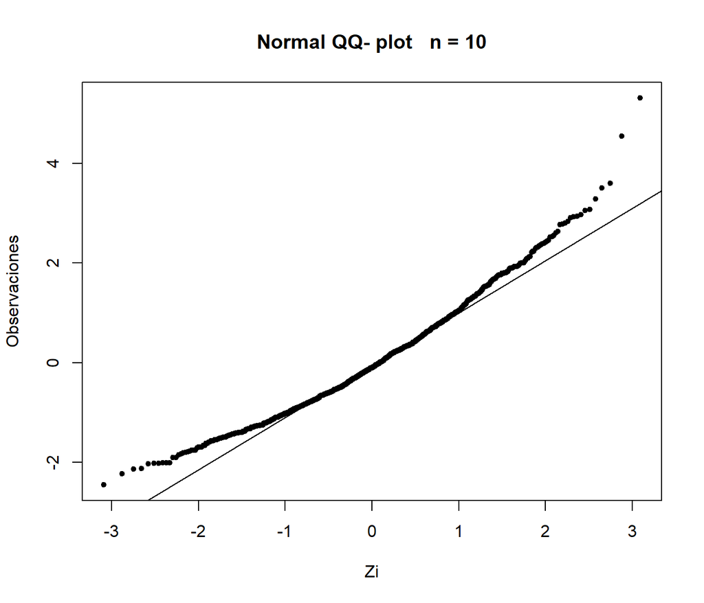

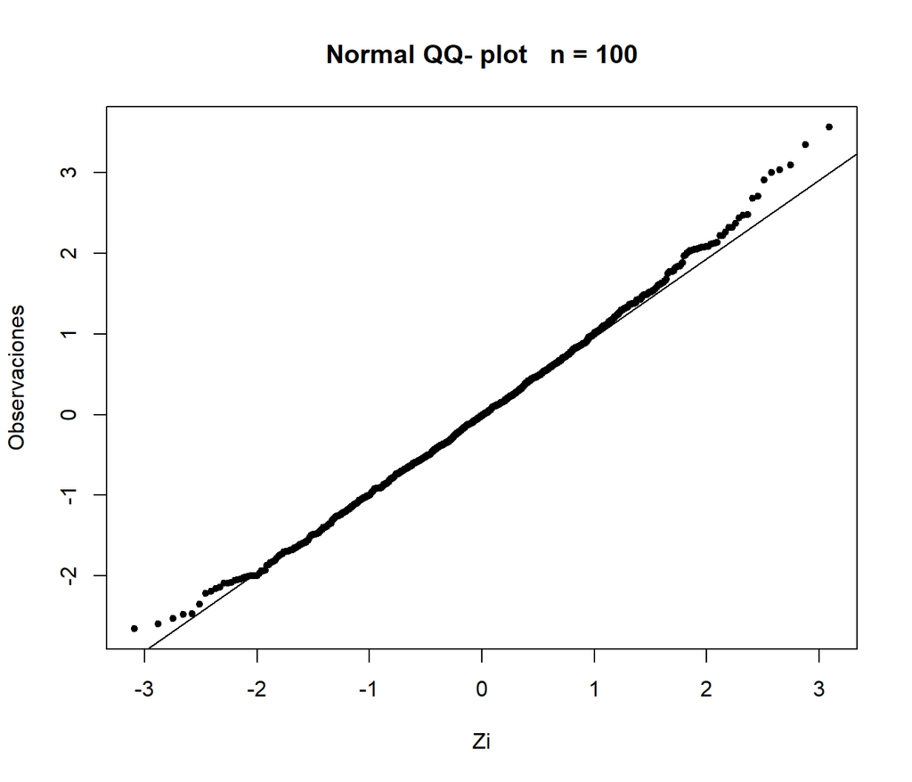

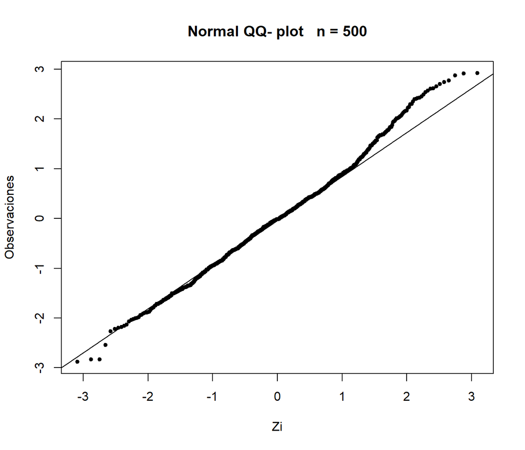

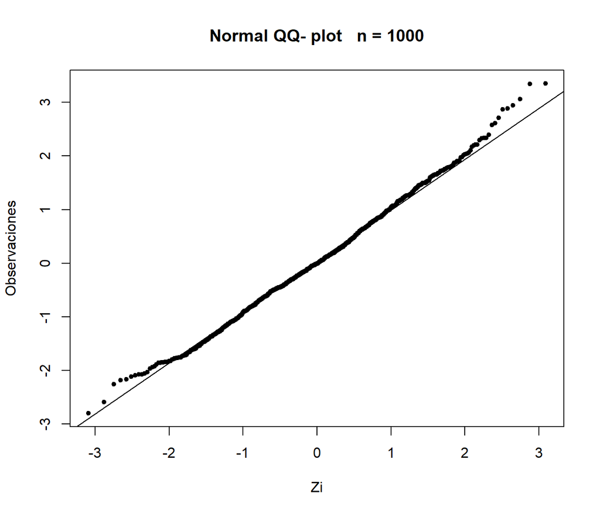

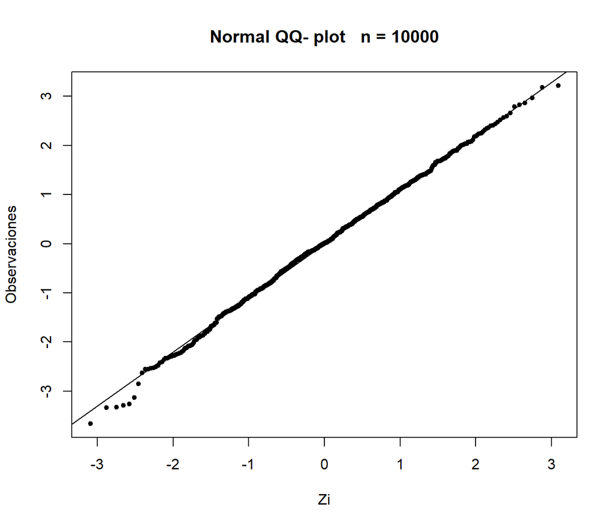

```r
i <- 1:6
auxiliar2 <- sapply(i, function(i) qqplotFunction(Muestra[ ,i], n[i]) )
```

Cuando la muestra es de n = 5, claramente se observa que presenta sesgo a la derecha (izquierda para el que observa). y por ende, no aproxima correctamente a una normal. Dicho sesgo, se va corrigiendo. Para una muestra de 10000 observaciones, la distribución mmuestral converge en distribución a una normal. Lo cual, se ve representado por el qq-plot (los puntos sobre la gráfica se encuntran sobre la recta).

En conclusión, bajo ciertas condiciones, al estandarizar las variables aleatorias cuya distribución es una exponencial, cuando la muestra (n) tiende a infinito (sea grande), entonces, la variable aleatoria estandarizada tiende a converger en distribución a una distribución límite normal estandar.

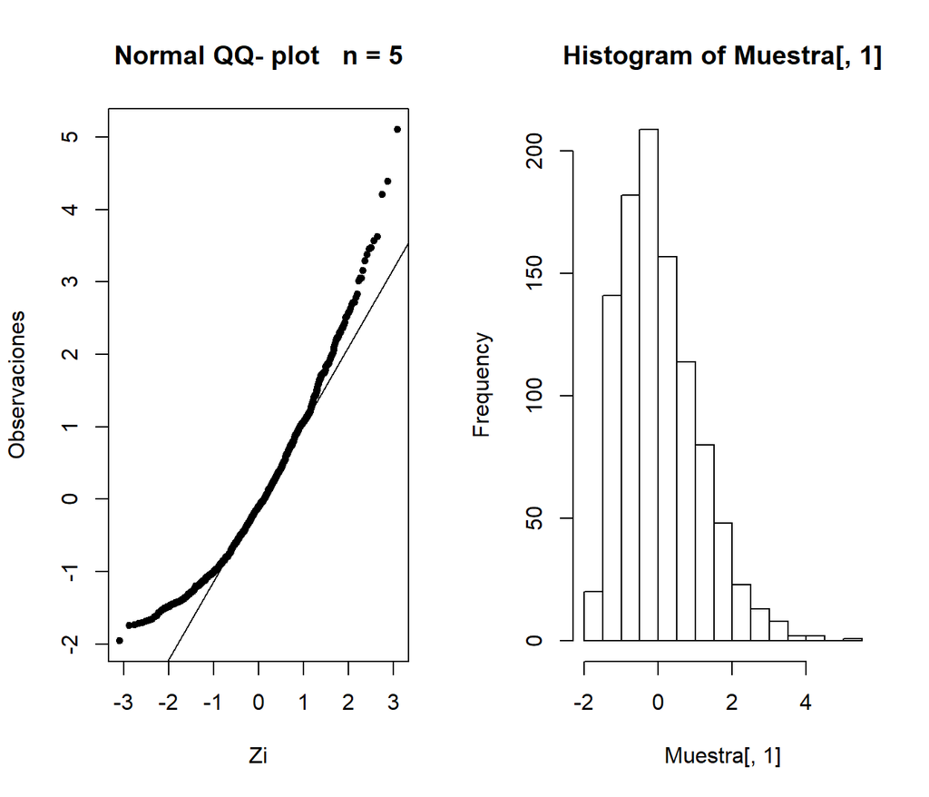

```r
#Caso en el que presenta sesgo a la derecha (izquierda para el que observa)
par(mfrow=c(1,2))
qqplotFunction(Muestra[ ,1], n[1])
hist(Muestra[ ,1])
```

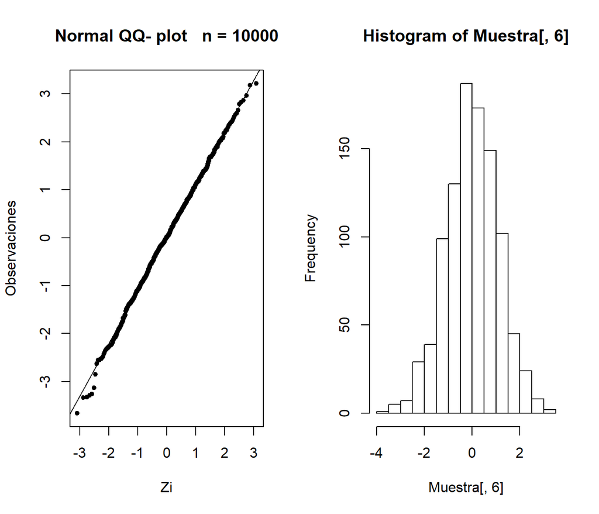

```r
#Caso en el que aproxima a una normal
par(mfrow=c(1,2))
qqplotFunction(Muestra[ ,6], n[6])
hist(Muestra[ ,6])
```

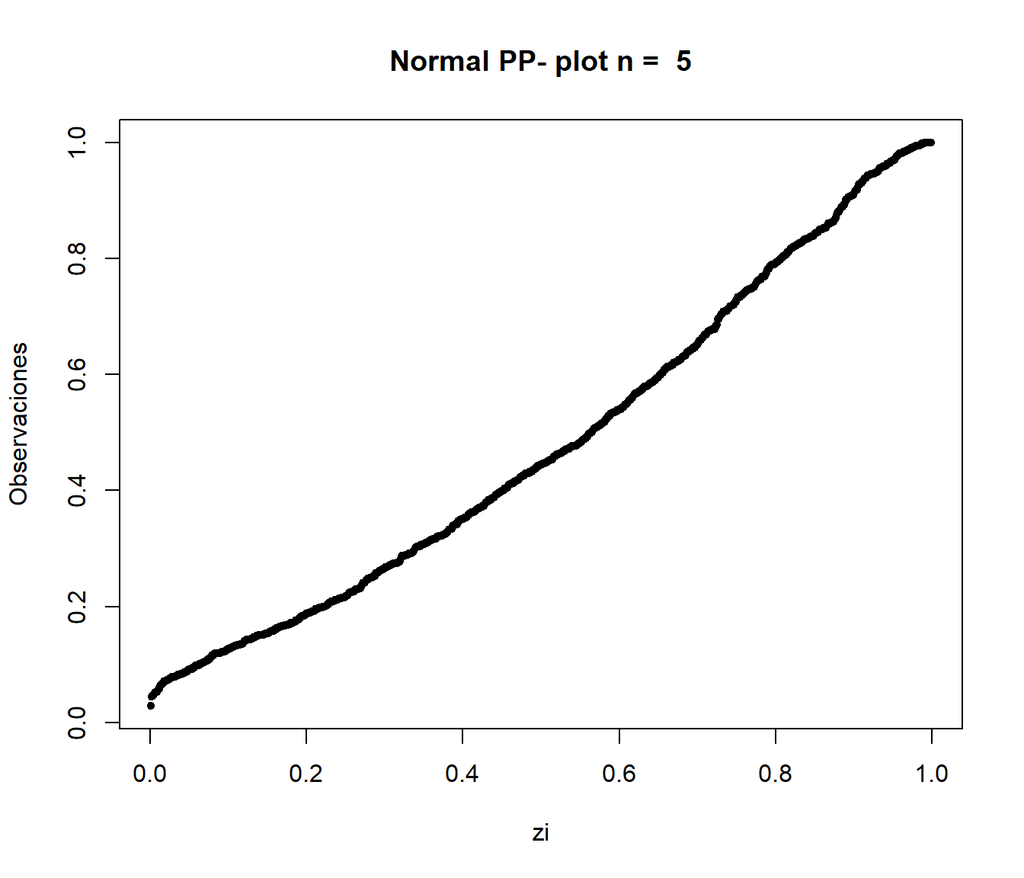

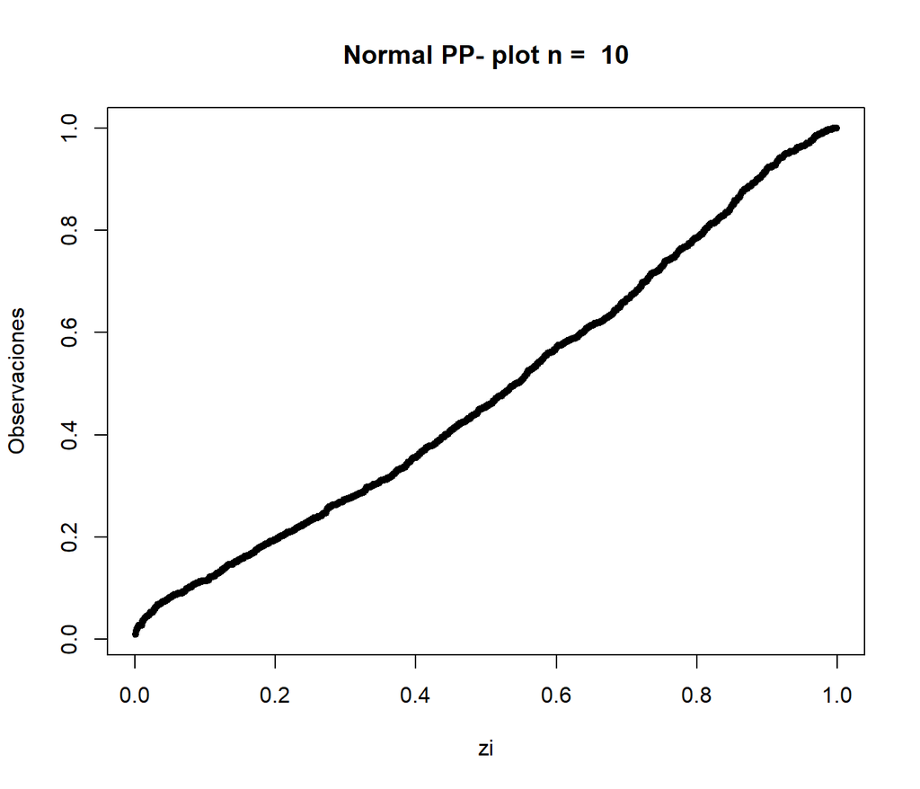

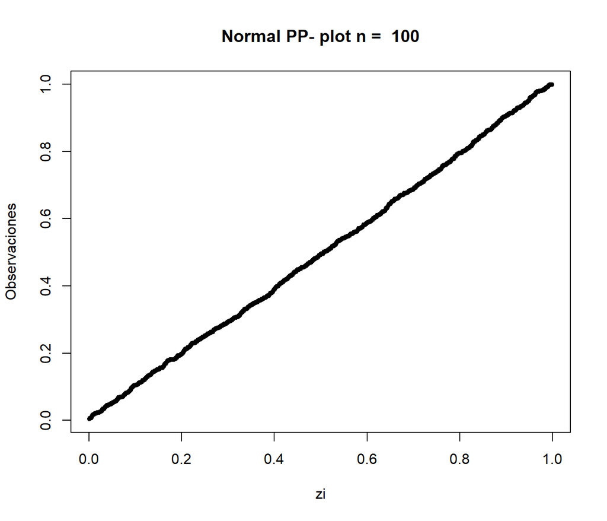

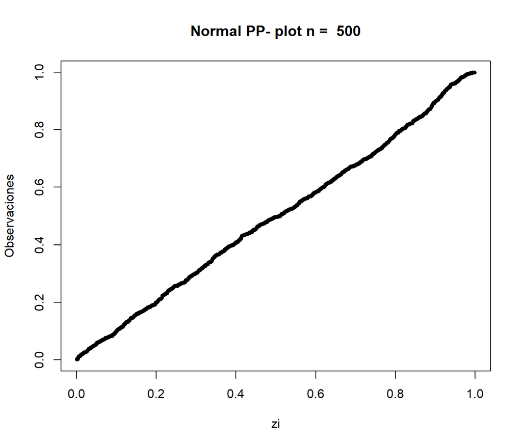

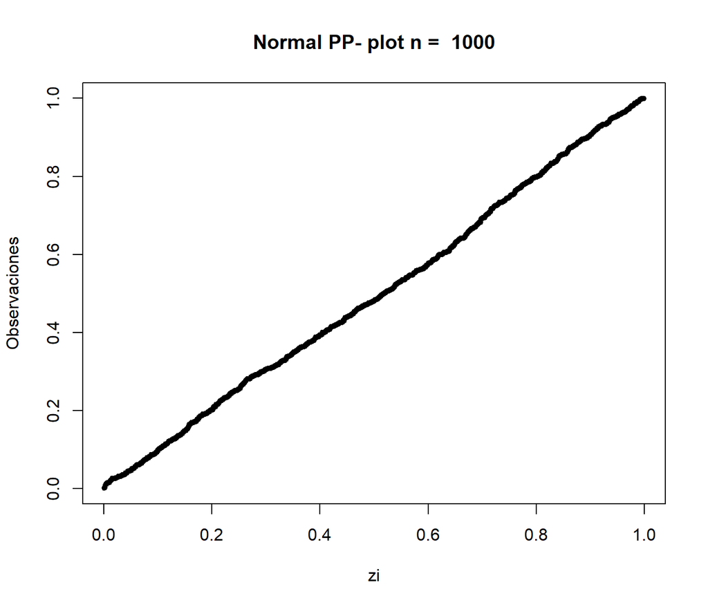

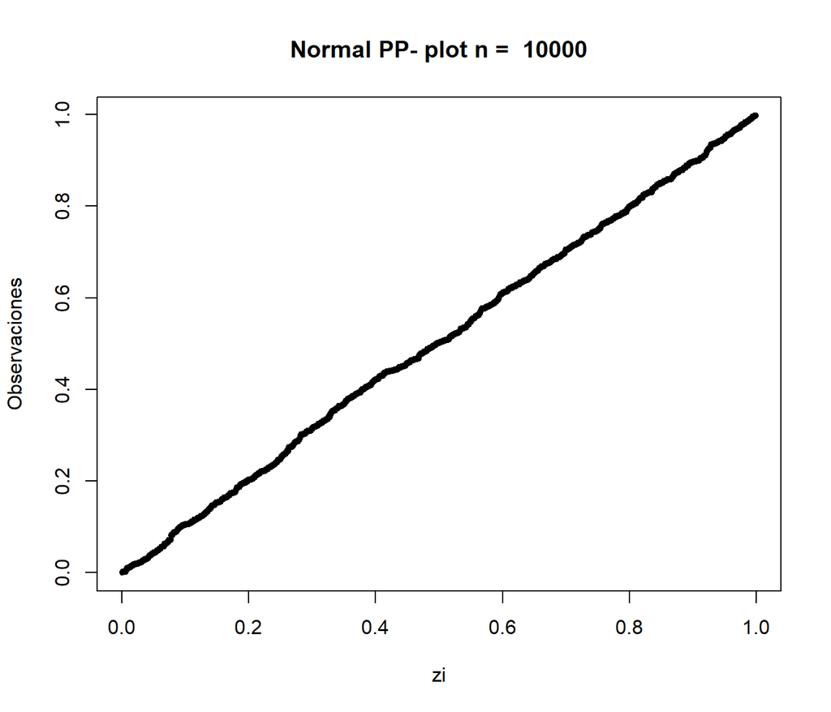

```r
pp_plotFunction<-function(data, sizeSample){
  n <- length(data)
  x <- 1:length(data)
  pest <- x/(n+1)
  teorico <-pnorm(c(0.25, 0.75))
  estimado <- c(0.25, 0.75)

  slope <- diff(estimado) / diff(teorico)
  int <- estimado[1] - slope * teorico[1]

  Fest <- pest
  Fn <- pnorm(sort(data), mean(data), sd(data))

  plot(Fest, Fn,  type = "p",
       ylab = "Observaciones", xlab ="zi",
       main = paste("Normal PP- plot n = ", sizeSample), pch=20)
}

pp_plotFunction(Muestra[ , 1], n[1])
i <- 1:6
auxiliar3 <- sapply(i, function(i) pp_plotFunction(Muestra[ ,i], n[i]) )
```

Al igual que en el qq-plot, los resultados y conclusiones con el pp-plot son los mismos (revisar lo anterior escrito).

## EJERCICIO 3

En este ejercicio volver´a a trabajar con el TCLC. a) Escriba una función análoga a la pedida en el inciso 2a) para una distribuciónn Binomial(p, N). La funciónn deber´a tomar los mismos parámetros a los pedidos en el inciso 2a), con excepción al parámetro $\lambda$ que tendrá que ser sustituido p y N.

```r
Zn2 <- function(n, p, N, m) {
  set.seed(0)
  Z <- rep(0, m)
  Z <- replicate(m, (sqrt(n)*(mean(rbinom(n, size = N, prob = p))-(N*p))/(sqrt(N*p*(1-p)))))
  return(Z)
}
```

2. Para p = 1/2 y N = 15, repita los incisos 2b) y 2c) para el caso Binomial de este ejercicio.

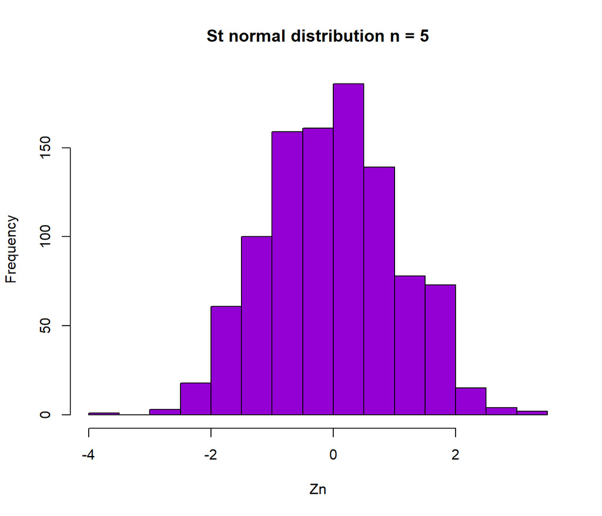

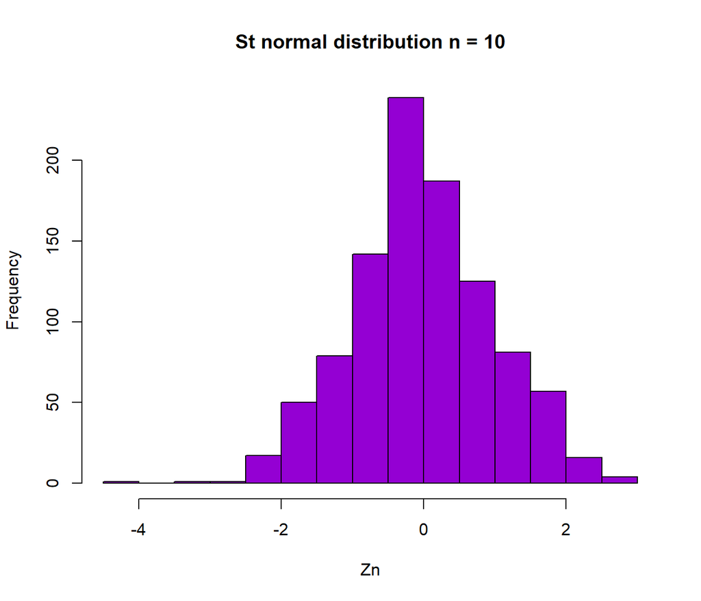

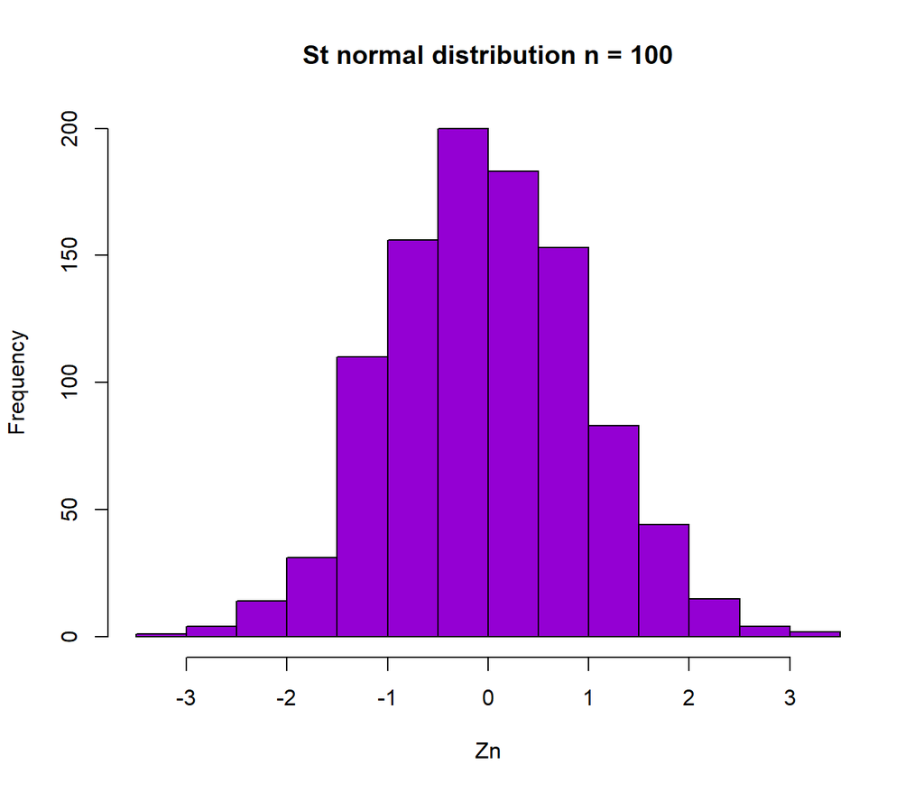

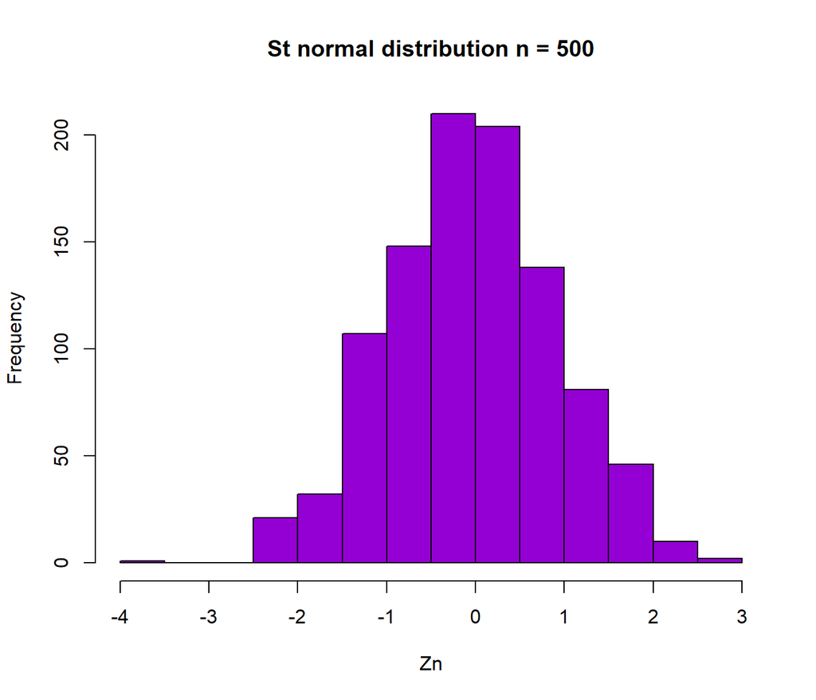

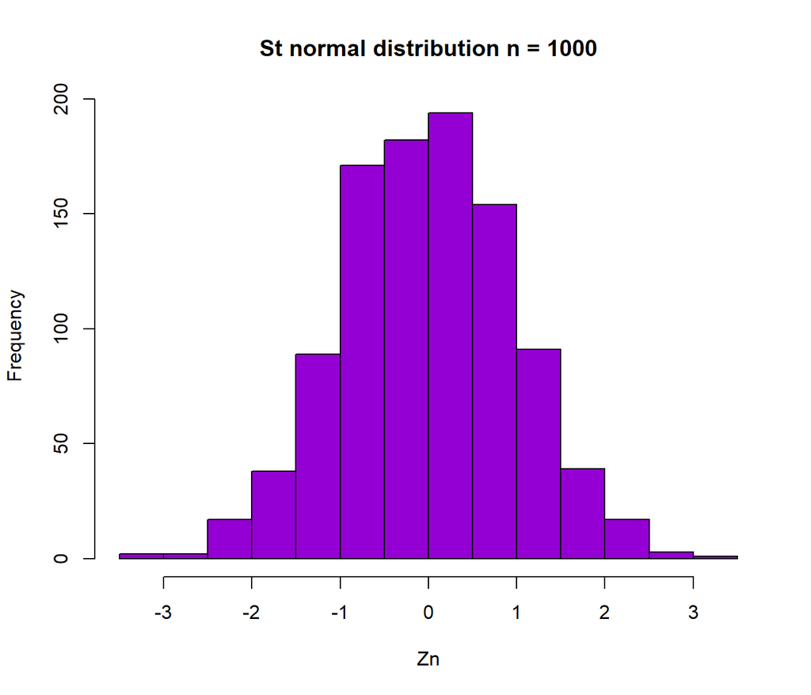

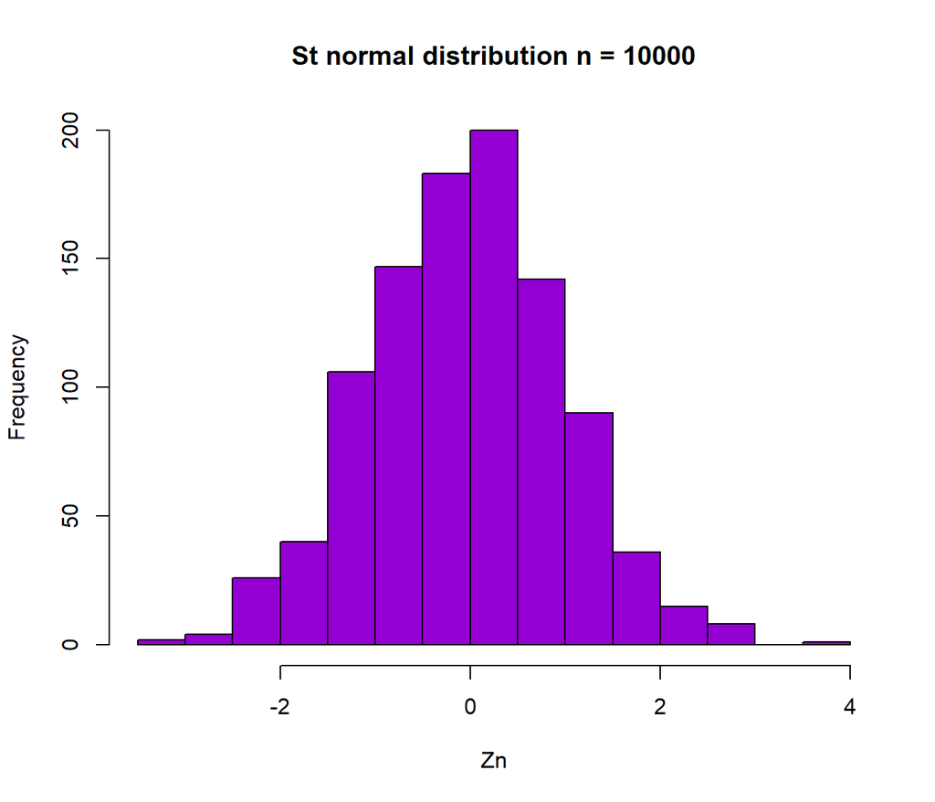

```r
n <- c(5, 10, 100, 500, 1000, 10000)
i <- 1:6
Muestra <<- matrix(0L, 1000, 6)
auxiliar <- sapply(i, function(i) hist(Muestra[, i] <<- Zn2(n[i], .5, 15,1000), main = paste("St normal distribution n =", n[i]),
                                       xlab = "Zn",  col ="darkviolet", border = "black") )
```